# Data Set for Analysis

•Titanic Data - Contains demographics and passenger information from 891 of the 2224 passengers and crew on board the Titanic. You can view a description of this dataset on the Kaggle website (https://www.kaggle.com/c/titanic/data), where the data was obtained.

# Questions I want to Answer from the data set:

•What factors made people more likely to survive?

- Were the Female, Child and Elders were rescued?
- Did the passenger of Pclass 1 get assistance for Survival?
- Were the people with parent or child, Sibling or Spouse survived more than those were alone?
- Were the people in Cabin survived more than the people without Cabin?
- Is there any correlation between age and survival?

•What is the average Fare for each Pclass?

•Is there any correlation between age & socio-economic status (SES)/Pclass?

# Data Wrangling

- Acquire the data
- Investigating the data and cleaning up any problems

## Acquire the data

```python
#Read 'titanic-data.csv'
import pandas as pd
titanic_data = pd.read_csv('titanic-data.csv')

titanic_data.head()
```

|  | PassengerId | Survived | Pclass | Name | Sex | Age | SibSp | Parch | Ticket | Fare | Cabin | Embarked |
| --- | --- | --- | --- | --- | --- | --- | --- | --- | --- | --- | --- | --- |
| 0 | 1 | 0 | 3 | Braund, Mr. Owen Harris | male | 22.0 | 1 | 0 | A/5 21171 | 7.2500 | NaN | S |
| 1 | 2 | 1 | 1 | Cumings, Mrs. John Bradley (Florence Briggs Th... | female | 38.0 | 1 | 0 | PC 17599 | 71.2833 | C85 | C |
| 2 | 3 | 1 | 3 | Heikkinen, Miss. Laina | female | 26.0 | 0 | 0 | STON/O2. 3101282 | 7.9250 | NaN | S |
| 3 | 4 | 1 | 1 | Futrelle, Mrs. Jacques Heath (Lily May Peel) | female | 35.0 | 1 | 0 | 113803 | 53.1000 | C123 | S |
| 4 | 5 | 0 | 3 | Allen, Mr. William Henry | male | 35.0 | 0 | 0 | 373450 | 8.0500 | NaN | S |

## Investigating the data and cleaning up any problems

```python
#Check count for each columns
titanic_data.count()
```

```
PassengerId    891
Survived       891
Pclass         891
Name           891
Sex            891
Age            714
SibSp          891
Parch          891
Ticket         891
Fare           891
Cabin          204
Embarked       889
dtype: int64
```

```python
#Remove Duplicate 'PassengerId', if any
titanic_data.drop_duplicates(subset=['PassengerId'], keep='first', inplace=True)
titanic_data.count()
```

```
PassengerId    891
Survived       891
Pclass         891
Name           891
Sex            891
Age            714
SibSp          891
Parch          891
Ticket         891
Fare           891
Cabin          204
Embarked       889
dtype: int64
```

```python
#Remove Duplicate 'Name', if any
titanic_data.drop_duplicates(subset=['Name'], keep='first', inplace=True)
titanic_data.count()
```

```
PassengerId    891
Survived       891
Pclass         891
Name           891
Sex            891
Age            714
SibSp          891
Parch          891
Ticket         891
Fare           891
Cabin          204
Embarked       889
dtype: int64
```

### Observation

- There are 2 passengers whose Embarkation Port (Embarked) is NaN
- There are 177 passengers whose age is not given in the data set
- 204 people were staying in Cabin

### handling missing values

###### 1) Embarkation Port:

There are 2 passengers whose Embarkation Port (Embarked) is NaN

No analysis is done involving Embarkation Port and these 2 passengers have all others data. So 2 Nan values in Embarkation Port has no effect on our analysis.

###### 2) Age:

There are 177 passengers whose Age is Nan.

a) When we analyse the correleation between 'Age' & 'Fare', we didn't consider the Passengers with Age as Nan

b) Pandas dataframe functions like mean(), groupby() ignore NaN Reference: http://pandas.pydata.org/pandas-docs/stable/missing_data.html

c) matplotlib.pyplot function plot(kind='hist') drops NaNs reference: http://pandas.pydata.org/pandas-docs/version/0.18.1/visualization.html

So missing values in Age are not filled using fillna()

###### 3) Cabin:

There are 687 NaN values in Cabin. NaN value in Cabin is treated as the passenger didn't have any Cabin.

We added a column "isCabinPassenger" with boolean values in titanic_data for Analysis in Exploration phase.

```python
#Passengers with no 'Embarked' record
boolean_series = titanic_data['Embarked'].isnull()
titanic_data[boolean_series]
```

|  | PassengerId | Survived | Pclass | Name | Sex | Age | SibSp | Parch | Ticket | Fare | Cabin | Embarked |
| --- | --- | --- | --- | --- | --- | --- | --- | --- | --- | --- | --- | --- |
| 61 | 62 | 1 | 1 | Icard, Miss. Amelie | female | 38.0 | 0 | 0 | 113572 | 80.0 | B28 | NaN |
| 829 | 830 | 1 | 1 | Stone, Mrs. George Nelson (Martha Evelyn) | female | 62.0 | 0 | 0 | 113572 | 80.0 | B28 | NaN |

```python
#Passengers with no 'Age' record
boolean_series = titanic_data['Age'].isnull()
titanic_data[boolean_series].head()
```

|  | PassengerId | Survived | Pclass | Name | Sex | Age | SibSp | Parch | Ticket | Fare | Cabin | Embarked |
| --- | --- | --- | --- | --- | --- | --- | --- | --- | --- | --- | --- | --- |
| 5 | 6 | 0 | 3 | Moran, Mr. James | male | NaN | 0 | 0 | 330877 | 8.4583 | NaN | Q |
| 17 | 18 | 1 | 2 | Williams, Mr. Charles Eugene | male | NaN | 0 | 0 | 244373 | 13.0000 | NaN | S |
| 19 | 20 | 1 | 3 | Masselmani, Mrs. Fatima | female | NaN | 0 | 0 | 2649 | 7.2250 | NaN | C |
| 26 | 27 | 0 | 3 | Emir, Mr. Farred Chehab | male | NaN | 0 | 0 | 2631 | 7.2250 | NaN | C |
| 28 | 29 | 1 | 3 | O'Dwyer, Miss. Ellen "Nellie" | female | NaN | 0 | 0 | 330959 | 7.8792 | NaN | Q |

# Exploration

Getting familiar with data, building intuition about it and finding patterns

```python
#Count of Male & Female Passenger
titanic_data.groupby(['Sex'], as_index=False).size()
```

```
Sex
female    314
male      577
dtype: int64
```

```python
#Were the female Survived more
sex_by_survived_data = titanic_data.groupby(['Sex','Survived'], as_index=False).size()
print sex_by_survived_data
```

```
Sex     Survived
female  0            81
        1           233
male    0           468
        1           109
dtype: int64
```

```python
#Count of Passenger in each Pclass
titanic_data.groupby(['Pclass'], as_index=False).size()
```

```
Pclass
1    216
2    184
3    491
dtype: int64
```

```python
#Insert a new column isCabinPassenger
boolean_series = titanic_data['Cabin'].notnull()
titanic_data['isCabinPassenger'] = boolean_series
titanic_data.head()
```

|  | PassengerId | Survived | Pclass | Name | Sex | Age | SibSp | Parch | Ticket | Fare | Cabin | Embarked | isCabinPassenger |
| --- | --- | --- | --- | --- | --- | --- | --- | --- | --- | --- | --- | --- | --- |
| 0 | 1 | 0 | 3 | Braund, Mr. Owen Harris | male | 22.0 | 1 | 0 | A/5 21171 | 7.2500 | NaN | S | False |
| 1 | 2 | 1 | 1 | Cumings, Mrs. John Bradley (Florence Briggs Th... | female | 38.0 | 1 | 0 | PC 17599 | 71.2833 | C85 | C | True |
| 2 | 3 | 1 | 3 | Heikkinen, Miss. Laina | female | 26.0 | 0 | 0 | STON/O2. 3101282 | 7.9250 | NaN | S | False |
| 3 | 4 | 1 | 1 | Futrelle, Mrs. Jacques Heath (Lily May Peel) | female | 35.0 | 1 | 0 | 113803 | 53.1000 | C123 | S | True |
| 4 | 5 | 0 | 3 | Allen, Mr. William Henry | male | 35.0 | 0 | 0 | 373450 | 8.0500 | NaN | S | False |

```python
#Were there cabins for only Pclass=1?
titanic_data.groupby(['Pclass','isCabinPassenger'], as_index=False).size()
```

```
Pclass  isCabinPassenger
1       False                40
        True                176
2       False               168
        True                 16
3       False               479
        True                 12
dtype: int64
```

```python
#Count of people Survived in each class
titanic_data.groupby(['Pclass','Survived'], as_index=False).size()
```

```
Pclass  Survived
1       0            80
        1           136
2       0            97
        1            87
3       0           372
        1           119
dtype: int64
```

```python
#Average Fare of Each Class people Survived in each class
titanic_data.groupby(['Pclass'], as_index=False).mean()
```

|  | Pclass | PassengerId | Survived | Age | SibSp | Parch | Fare | isCabinPassenger |
| --- | --- | --- | --- | --- | --- | --- | --- | --- |
| 0 | 1 | 461.597222 | 0.629630 | 38.233441 | 0.416667 | 0.356481 | 84.154687 | 0.814815 |
| 1 | 2 | 445.956522 | 0.472826 | 29.877630 | 0.402174 | 0.380435 | 20.662183 | 0.086957 |
| 2 | 3 | 439.154786 | 0.242363 | 25.140620 | 0.615071 | 0.393075 | 13.675550 | 0.024440 |

```python
#Average Fare of Each Class people Survived in each class
titanic_data.groupby(['Pclass','isCabinPassenger'], as_index=False)['Survived','Age','Fare'].mean()
```

|  | Pclass | isCabinPassenger | Survived | Age | Fare |
| --- | --- | --- | --- | --- | --- |
| 0 | 1 | False | 0.475000 | 41.230769 | 76.848643 |
| 1 | 1 | True | 0.664773 | 37.746375 | 85.815152 |
| 2 | 2 | False | 0.440476 | 30.315380 | 20.909673 |
| 3 | 2 | True | 0.812500 | 25.266667 | 18.063544 |
| 4 | 3 | False | 0.235908 | 25.260638 | 13.725077 |
| 5 | 3 | True | 0.500000 | 21.000000 | 11.698608 |

```python
#Did cabin passenger survive more?
titanic_data.groupby(['isCabinPassenger', 'Survived'], as_index=False).size()
```

```
isCabinPassenger  Survived
False             0           481
                  1           206
True              0            68
                  1           136
dtype: int64
```

```python
#Number of passenger with Only SibSp
passenger_SibSp = titanic_data[(titanic_data['SibSp']>=1) & ~(titanic_data['Parch']>=1)]
#len(passenger_SibSp)
passenger_SibSp_Stat = passenger_SibSp.groupby('Survived').size()
passenger_SibSp_Stat
```

```
Survived
0    71
1    70
dtype: int64
```

```python
#Number of passenger with Only Parch
passenger_Parch = titanic_data[(titanic_data['Parch']>=1) & ~(titanic_data['SibSp']>=1)]
#len(passenger_Parch)
passenger_Parch_Stat = passenger_Parch.groupby('Survived').size()
passenger_Parch_Stat
```

```
Survived
0    24
1    47
dtype: int64
```

```python
#Number of passenger with SibSp & Parch
passenger_SibSp_Parch = titanic_data[(titanic_data['SibSp']>=1) & (titanic_data['Parch']>=1)]
#len(passenger_SibSp_Parch)
passenger_SibSp_Parch_Stat = passenger_SibSp_Parch.groupby('Survived').size()
passenger_SibSp_Parch_Stat
```

```
Survived
0    80
1    62
dtype: int64
```

```python
#Number of passenger with Alone
passenger_Alone = titanic_data[~((titanic_data['SibSp']>=1) | (titanic_data['Parch']>=1))]
passenger_Alone_Stat = passenger_Alone.groupby(['Survived']).size()
#len(passenger_Alone)
passenger_Alone.groupby(['Survived','Sex']).size()
```

```
Survived  Sex
0         female     27
          male      347
1         female     99
          male       64
dtype: int64
```

```python
#Minimun Age of Passenger
print 'Minimum Passenger Age {}'.format(titanic_data['Age'].min())
print 'Maximum Passenger Age {}'.format(titanic_data['Age'].max())
print 'Mean Passenger Age {} and Standard Deviation {}'.format(titanic_data['Age'].mean(),titanic_data['Age'].std())
```

```
Minimum Passenger Age 0.42
Maximum Passenger Age 80.0
Mean Passenger Age 29.6991176471 and Standard Deviation 14.5264973323
```

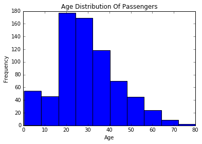

```python
%pylab inline

import matplotlib.pyplot as plt
titanic_data['Age'].plot(kind='hist')
plt.xlabel('Age')
plt.title("Age Distribution Of Passengers")
plt.show()
```

```python
Below_Age16_Passenger = titanic_data[titanic_data['Age'] <16]
Children_Stat = Below_Age16_Passenger.groupby(['Survived']).size()
Children_Stat
```

```
Survived
0    34
1    49
dtype: int64
```

```python
Above_Age60_Passenger = titanic_data[titanic_data['Age'] >60]
Elder_Stat = Above_Age60_Passenger.groupby(['Survived']).size()
Elder_Stat
```

```
Survived
0    17
1     5
dtype: int64
```

# Conclusions & Communicate

Conclusion: This phase usually involves statistics or machine learning

Communicate: Data visualization is a common technique that's almost always useful when communicating findings about data.

```python
#Were the Female, child & old people were rescued?
sex_by_survived_data = titanic_data.groupby(['Sex','Survived'], as_index=False).size()

percentage_male_survived = float(sex_by_survived_data['male'][1]) / (sex_by_survived_data['male'][0]+ + sex_by_survived_data['male'][1]) * 100
percentage_female_survived = float(sex_by_survived_data['female'][1]) / (sex_by_survived_data['female'][0]+ + sex_by_survived_data['female'][1]) * 100

print "Percentage of male Survived {} & percentage of female survived {}".format(percentage_male_survived, percentage_female_survived)
```

```
Percentage of male Survived 18.8908145581 & percentage of female survived 74.2038216561
```

```python
percentage_children_survived = float(Children_Stat[1]) / (Children_Stat[0]+ Children_Stat[1]) * 100
percentage_children_survived
```

```
59.036144578313255
```

```python
percentage_elder_survived = float(Elder_Stat[1]) / (Elder_Stat[0]+ + Elder_Stat[1]) * 100
percentage_elder_survived
```

```
22.727272727272727
```

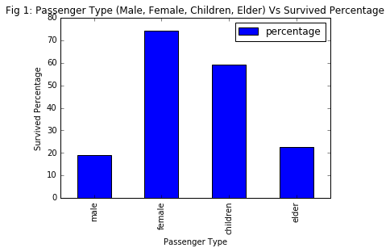

```python
survival_percentage = pd.DataFrame({'percentage': [percentage_male_survived, percentage_female_survived, percentage_children_survived, percentage_elder_survived]},
                       index=['male', 'female', 'children', 'elder'])


%pylab inline

import matplotlib.pyplot as plt
#survival_percentage.plot(kind='pie',subplots=True)
survival_percentage.plot(kind='bar')
plt.xlabel('Passenger Type')
plt.ylabel('Survived Percentage')
plt.title("Fig 1: Passenger Type (Male, Female, Children, Elder) Vs Survived Percentage")
plt.show()
```

### Conclusion: Were the Female, children and elders rescued?

Percentage of female passenger survived is: 74.20, Percentage of children survived is: 59.02. These are signifactly higher than the male passenger survived: 18.89.  
Thus we can conclude that female & children were rescued first. The survival percentage of elder passenger is 22.72 which is not significantly higher than male survival rate.

```
Pclass
1    62.962963
2    47.282609
3    24.236253
Name: Survived, dtype: float64
```

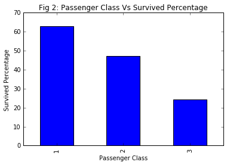

```python
#Count of people Survived in each class
#passenger_by_class = titanic_data.groupby(['Pclass'], as_index=False)
#survived_by_class = titanic_data.groupby(['Pclass','Survived'], as_index=False)

#survival_percentage_by_class = pd.Series()
#for pclass in range(1,4):
#    class_name = "Pclass" + str(pclass)
#    survival_percentage_by_class[class_name] = float(len(survived_by_class.get_group((pclass,1))))/ len(passenger_by_class.get_group(pclass)) * 100
survival_percentage_by_class = titanic_data.groupby(['Pclass'])['Survived'].mean() * 100

print survival_percentage_by_class
survival_percentage_by_class.plot(kind='bar')

plt.xlabel('Passenger Class')
plt.ylabel('Survived Percentage')
plt.title("Fig 2: Passenger Class Vs Survived Percentage")
plt.show()
```

### Conclusion: Did the passenger of Pclass 1 get assistance for Survival??

Survival rate of passengers in Pclass 1 is highest among the other classes.

```
isCabinPassenger
False    29.985444
True     66.666667
Name: Survived, dtype: float64
```

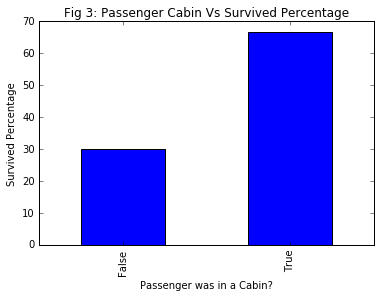

```python
#Count of people Survived by Cabin
#passenger_by_class = titanic_data.groupby(['isCabinPassenger'], as_index=False)
#survived_by_class = titanic_data.groupby(['isCabinPassenger','Survived'], as_index=False)

#survival_percentage_by_class = pd.Series()
#for pclass in range(0,2):
#    if pclass==0:
#        class_name = "General"
#    else:
#        class_name = "Cabin"
#    survival_percentage_by_class[class_name] = float(len(survived_by_class.get_group((pclass,1))))/ len(passenger_by_class.get_group(pclass)) * 100

survival_percentage_by_cabin = titanic_data.groupby(['isCabinPassenger'])['Survived'].mean() * 100

print survival_percentage_by_cabin
survival_percentage_by_cabin.plot(kind='bar')
plt.xlabel('Passenger was in a Cabin?')
plt.ylabel('Survived Percentage')
plt.title("Fig 3: Passenger Cabin Vs Survived Percentage")
plt.show()
```

```python
#Were there cabins for only Pclass=1?
titanic_data.groupby(['Pclass','isCabinPassenger','Survived'], as_index=False).size()
```

```
Pclass  isCabinPassenger  Survived
1       False             0            21
                          1            19
        True              0            59
                          1           117
2       False             0            94
                          1            74
        True              0             3
                          1            13
3       False             0           366
                          1           113
        True              0             6
                          1             6
dtype: int64
```

```
SibSp Only         49.645390
Parch Only         66.197183
SibSp And Parch    43.661972
Alone              30.353818
dtype: float64
```

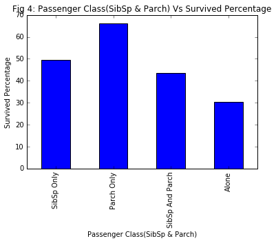

```python
survived_percentage_SibSp = float(passenger_SibSp_Stat[1])/(passenger_SibSp_Stat[0] + passenger_SibSp_Stat[1]) * 100
survived_percentage_Parch = float(passenger_Parch_Stat[1])/(passenger_Parch_Stat[0] + passenger_Parch_Stat[1]) * 100
survived_percentage_SibSp_Parch = float(passenger_SibSp_Parch_Stat[1])/(passenger_SibSp_Parch_Stat[0] + passenger_SibSp_Parch_Stat[1]) * 100
survived_percentage_Alone = float(passenger_Alone_Stat[1])/(passenger_Alone_Stat[0] + passenger_Alone_Stat[1]) * 100

survival_percentage_by_Type = pd.Series()
survival_percentage_by_Type["SibSp Only"] = survived_percentage_SibSp
survival_percentage_by_Type["Parch Only"] = survived_percentage_Parch
survival_percentage_by_Type["SibSp And Parch"] = survived_percentage_SibSp_Parch
survival_percentage_by_Type["Alone"] = survived_percentage_Alone

print survival_percentage_by_Type
survival_percentage_by_Type.plot(kind='bar')

plt.xlabel('Passenger Class(SibSp & Parch)')
plt.ylabel('Survived Percentage')
plt.title("Fig 4: Passenger Class(SibSp & Parch) Vs Survived Percentage")
plt.show()
```

### Conclusion: Were the people with parent or child, Sibling or Spouse survived more than those were alone?

People with Parch (parent or child) and SibSp (sibling or soupse) survived more than the people who were alone.

```python
#Average Fare of Each Class people Survived in each class
fare_stat = titanic_data.groupby(['Pclass','isCabinPassenger'], as_index=False)['Survived','Age','Fare'].mean()
fare_stat
```

|  | Pclass | isCabinPassenger | Survived | Age | Fare |
| --- | --- | --- | --- | --- | --- |
| 0 | 1 | False | 0.475000 | 41.230769 | 76.848643 |
| 1 | 1 | True | 0.664773 | 37.746375 | 85.815152 |
| 2 | 2 | False | 0.440476 | 30.315380 | 20.909673 |
| 3 | 2 | True | 0.812500 | 25.266667 | 18.063544 |
| 4 | 3 | False | 0.235908 | 25.260638 | 13.725077 |
| 5 | 3 | True | 0.500000 | 21.000000 | 11.698608 |

```python
boolean_series = titanic_data['Age'].notnull()
titanic_data_with_age = titanic_data[boolean_series].head()
#titanic_data_with_age.head()
```

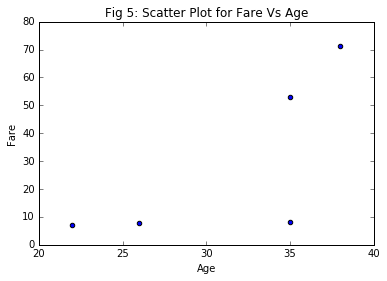

```python
%pylab inline
import matplotlib.pyplot as plt

titanic_data_with_age.plot(kind='scatter', x='Age', y='Fare')
plt.title("Fig 5: Scatter Plot for Fare Vs Age")
plt.show()
```

```python
def correlation(x, y):
    '''
    Fill in this function to compute the correlation between the two
    input variables. Each input is either a NumPy array or a Pandas
    Series.

    correlation = average of (x in standard units) times (y in standard units)

    Remember to pass the argument "ddof=0" to the Pandas std() function!
    '''
    std_x = (x - x.mean()) / x.std(ddof=0)
    std_y = (y - y.mean()) / y.std(ddof=0)
    return (std_x * std_y).mean()

age = titanic_data_with_age['Age']
fare = titanic_data_with_age['Fare']
print correlation(age, fare)
```

```
0.730447787604
```

# Conclusion

I wanted to find out the factors that made people more likely to survive when titanic was sinking. So I calculated the survival percentage for male, female, children & elder passengers.

#### Analysis-1: Who Survived Male or Female?

We know that women, children & elder people get priority in case of disaster, I wanted to find out if they were rescued first in case of titanic.

From the Bar Plot in Fig 1, we can see that the percentage of survival in female passenger is 74.20% where the percentage of survival among male passenger is only 18.89%.

Survival percentage of female passenger is approximately 4 times than the male passenger. So we can infer that female passenger were rescuded as titanic was sinking.

From Fig-1, we can also infer that children (below 16 years) were rescued but Elders might not be rescued.

#### Analysis-2: Did passengers with better socio-economic status (SES) get privilege?

As we see in our society that people with better SES get more privilege. I wanted to find if that also held true during the rescue operation of Titanic. I calculated the survival percentage of each class of passenger to investigate.

From Fig 2, we can see that percentage of survival of Upper Class is 62.96%, Middle Class is 47.28% & Lower Class is 24.23%

Thus we can infer that people in Upper Class were survived more than the people of Middle and Lower Class

#### Analysis-3: Did passengers with relatives survived more than the passengers without relative?

From Fig -4, we can see that the percentage of Survival is more for passengers with one or more relatives compared to those who were alone.

#### Analysis-4: Is there any correlation between the Age and socio-economic status (SES)?

I plotted a scatter plot in Fig 5 to investigate the correlation between Age & Fare.

#### Not able to analyze: Age Vs Survived

I wanted to find if there is any correlation between age and survival? But I couldn't establish that from the dataset.  
There is no significat difference between the mean age of Survived & non-Survived passengers. From the analysis it seems that gender (female), class, relatives in the ship helped people to survive.

```python
titanic_data.groupby("Survived")["Age"].mean()
```

```
Survived
0    30.626179
1    28.343690
Name: Age, dtype: float64
```